# APD Project 2

2024-02-17

## Analyzing Trends of FEMA Claims Over Time

```r
library(httr)
library(jsonlite)
library(dplyr)
url <- GET("https://www.fema.gov/api/open/v2/FimaNfipClaims")
my_content <- content(url, as = 'text')
json_content <- fromJSON(my_content)
data <- fromJSON(rawToChar(url$content))
claims <- data$FimaNfipClaims
```

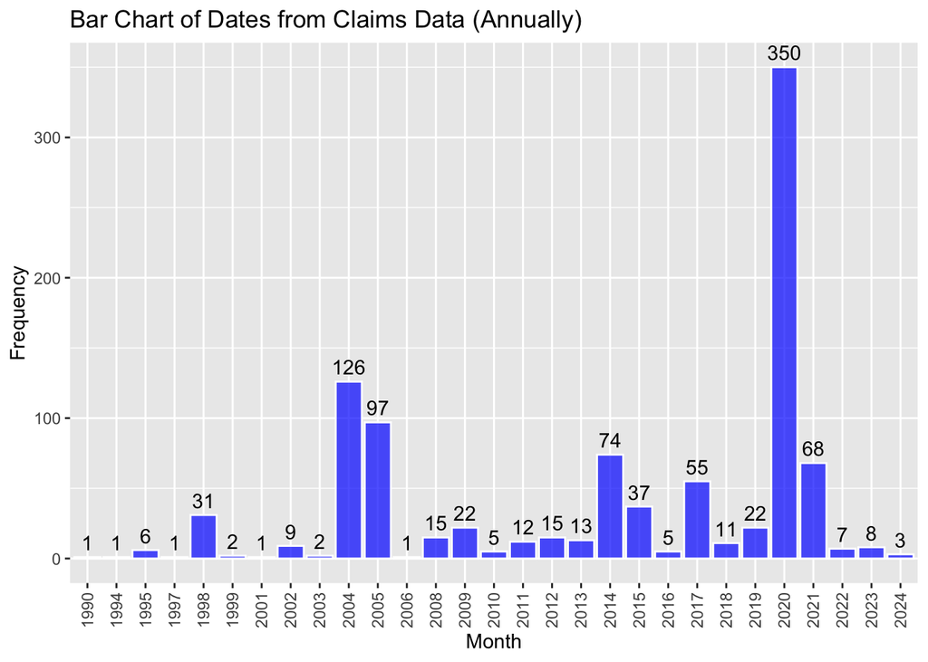

```r
library(lubridate)
library(ggplot2)
library(plotly)

#get annual frequency of claims
claims$dateOfLoss <- as.Date((claims$dateOfLoss), format = "%Y-%m-%d")
claims$year <- format(claims$dateOfLoss, "%Y")

# Plot bar chart with annual frequency
ggplot(claims, aes(x = year)) +
  geom_bar(fill = "blue", color = "white", alpha = 0.7) +
  labs(title = "Bar Chart of Dates from Claims Data (Annually)",
       x = "Month",
       y = "Frequency") + theme(axis.text.x = element_text(angle=90, vjust=.5, hjust=1)) + geom_text(aes(label = ..count..), stat = "count", vjust = -0.5, colour = "black", color="white")
```

Plotted annual data to see if there was a trend in the number of FEMA claims over time. According to the chart, there seems to be no visible trend. There were peaks in NFIP claims around 2004-2005 and 2020.

According to E&E News https://www.eenews.net/articles/analysis-8-counties-got-half-of-2020-flood-claims/,

“Eight counties — in Alabama, Florida and Louisiana — accounted for half of the claims payments, which arose from a series of storms that caused major but not catastrophic damage during last year’s record-breaking Atlantic hurricane season. There were a record 30 named storms from June to December including 13 hurricanes and six major hurricanes reaching Category 3 or higher.

Hurricane Sally, a Category 2 storm in September that hit the Gulf Coast in Alabama and Florida, accounted for roughly one-third of the claims paid by the National Flood Insurance Program in 2020.”

## Observing types of buildings that are most impacted as reported by the number of claims:

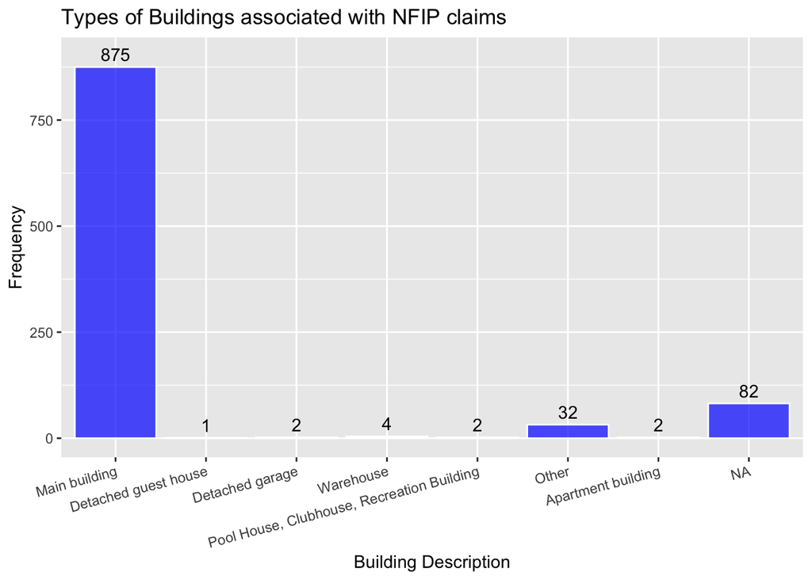

```r
library(lubridate)
library(ggplot2)
library(plotly)

# Define the labels for the building description codes
building_labels <- c("1" = "Main building",
                     "2" = "Detached guest house",
                     "3" = "Detached garage",
                     "5" = "Warehouse",
                     "6" = "Pool House, Clubhouse, Recreation Building",
                     "8" = "Other",
                     "10" = "Apartment building")

# Plot bar chart of types of buildings affected
ggplot(claims, aes(x = factor(buildingDescriptionCode, labels = building_labels))) +
  geom_bar(fill = "blue", color = "white", alpha = 0.7) +
  labs(title = "Types of Buildings associated with NFIP claims",
       x = "Building Description",
       y = "Frequency") +
  scale_y_continuous(limits = c(0, 900)) +
  geom_text(aes(label = ..count..), stat = "count", vjust = -0.5, colour = "black") +
  theme(axis.text.x = element_text(angle = 15, hjust = 1)) # Rotate x labels for readability
```

## States that Had the Most NFIP Claims

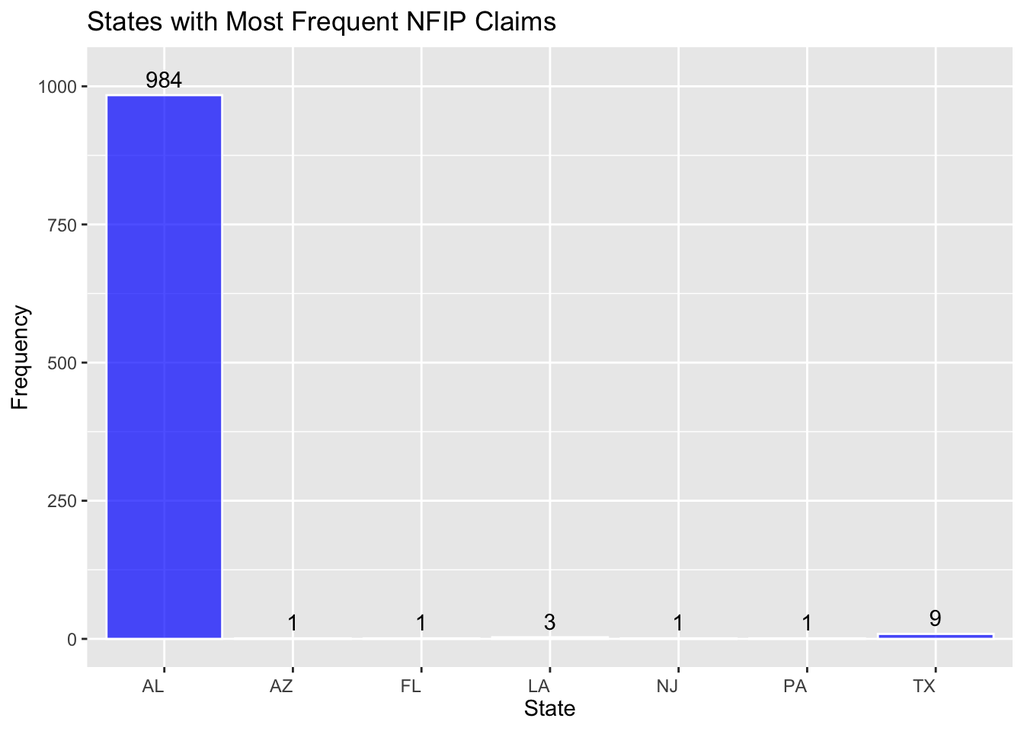

```r
library(lubridate)
library(ggplot2)
library(plotly)

#plot bar chart of states with FEMA claims
ggplot(claims, aes(x = state)) +
  geom_bar(fill = "blue", color = "white", alpha = 0.7) +
  labs(title = "States with Most Frequent NFIP Claims",
       x = "State", y = "Frequency") + theme(axis.text.x = element_text(angle=0, vjust=.5, hjust=1)) + scale_y_continuous(limits = c(0,1020)) + geom_text(aes(label = ..count..), stat = "count", vjust = -0.5, colour = "black")
```

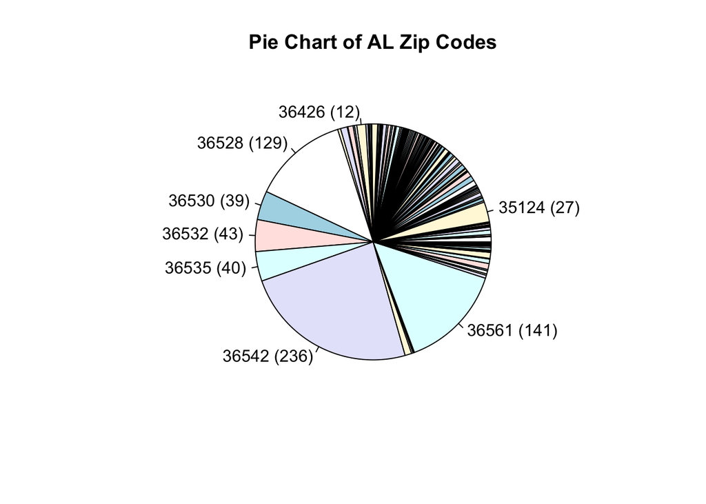

```r
#pie chart of Alabama zipcodes with most frequent NFIP claims
AL_zipcodes = table(subset(claims, state == 'AL', select = reportedZipCode))
lbls <- as.numeric(AL_zipcodes)
labels_with_freq <- ifelse(lbls > 10, paste(names(AL_zipcodes), " (", lbls, ")", sep = ""), "")
pie(AL_zipcodes, labels = labels_with_freq, main="Pie Chart of AL Zip Codes")
```

Alabama, by a land slide, is the state that had most NFIP claims. This is consistent with the news article shown prior as well.

The pie chart delved deeper into the state of Alabama by looking at the zip codes that had the most claims tied to it.

36542- Baldwin County 36561- Baldwin County 36528- Dauphin Island 36532- Baldwin County 36535- Baldwin County

Baldwin County is on the Gulf Coast and borders the Gulf of Mexico. This explains the number of claims espeically in 2020 when Hurrican Sally hit the Gulf Coast.

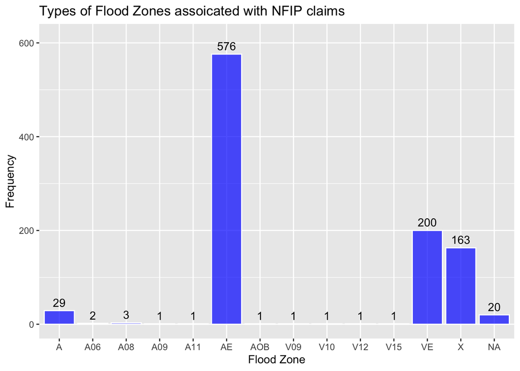

```r
# Plot bar chart of floodzone frequencies
ggplot(claims, aes(x = floodZoneCurrent)) +
  geom_bar(fill = "blue", color = "white", alpha = 0.7) +
  labs(title = "Types of Flood Zones assoicated with NFIP claims ",
       x = "Flood Zone",
       y = "Frequency") + scale_y_continuous(limits = c(0,610)) + geom_text(aes(label = ..count..), stat = "count", vjust = -0.5, colour = "black")
```

Zone A, Zones A1-A30, Zone AE, Zone AO, Zone V, Zone VE, and Zones V1-V30 are Special Flood Hazard Areas (SFHAs). These are defined as areas that will likely be inundated by the flood event having a 1-percent chance of being equaled or exceeded in any given year.

Zone X is a moderate flood hazard area which is between the limits of the base flood and the 0.2-percent-annual-chance flood.

```r
#States with SFHA

#index by zones that are SFHA
states_SFHA = table(subset(claims, floodZoneCurrent == 'A' | floodZoneCurrent == 'A06' | floodZoneCurrent == 'A08' | floodZoneCurrent == 'A09' | floodZoneCurrent == 'A11' | floodZoneCurrent == 'AE' | floodZoneCurrent == 'AOB' | floodZoneCurrent == 'V09' | floodZoneCurrent == 'V10' | floodZoneCurrent == 'V12' | floodZoneCurrent == 'V15' | floodZoneCurrent == 'VE', select = state))
lbls <- as.numeric(states_SFHA)
print(states_SFHA)
```

```
## state
##  AL  LA  NJ
## 814   2   1
```

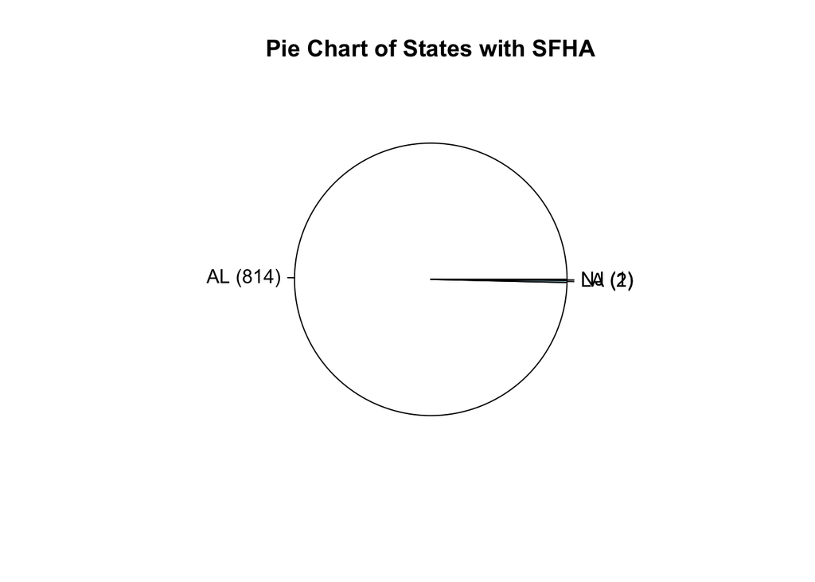

```r
labels_with_freq <- paste(names(states_SFHA), " (", lbls, ")", sep = "")
pie(states_SFHA, labels = labels_with_freq, main="Pie Chart of States with SFHA")
```

```r
#moderate flood hazard area

#index by zones that are MFHA
states_MFHA = table(subset(claims, floodZoneCurrent == 'X', select = state))
lbls <- as.numeric(states_MFHA)
print(states_MFHA)
```

```
## state
##  AL
## 163
```

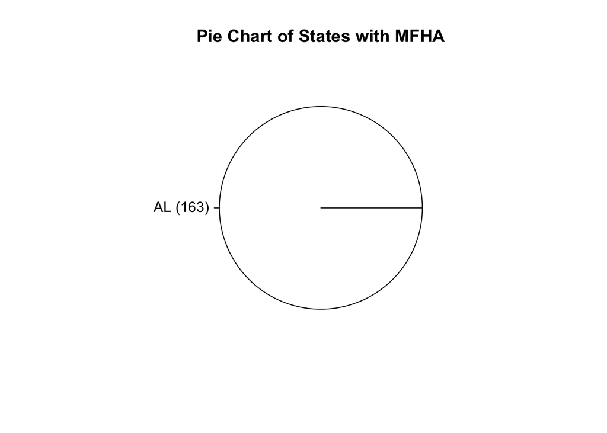

```r
labels_with_freq <- paste(names(states_MFHA), " (", lbls, ")", sep = "")
pie(states_MFHA, labels = labels_with_freq, main="Pie Chart of States with MFHA")
```

## What Caused the Most Flood Damage?

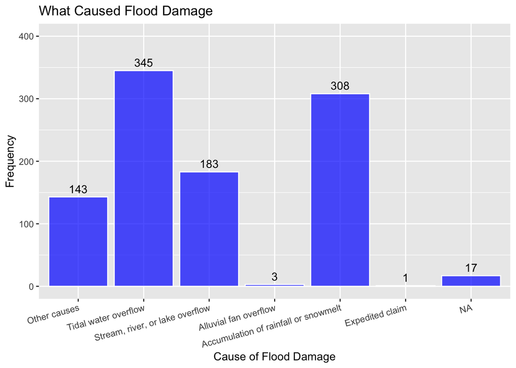

```r
# Define the labels for the causes of damage
cause_labels <- c("0" = "Other causes",
                  "1" = "Tidal water overflow",
                  "2" = "Stream, river, or lake overflow",
                  "3" = "Alluvial fan overflow",
                  "4" = "Accumulation of rainfall or snowmelt",
                  "B" = "Expedited claim")

# Plot bar chart with frequency of cause of damage with labels
ggplot(claims, aes(x = factor(causeOfDamage, labels = cause_labels))) +
  geom_bar(fill = "blue", color = "white", alpha = 0.7) +
  labs(title = "What Caused Flood Damage",
       x = "Cause of Flood Damage",
       y = "Frequency") +
  scale_y_continuous(limits = c(0, 400)) +
  geom_text(aes(label = ..count..), stat = "count", vjust = -0.5, color = "black") +
  theme(axis.text.x = element_text(angle = 15, hjust = 1))
```

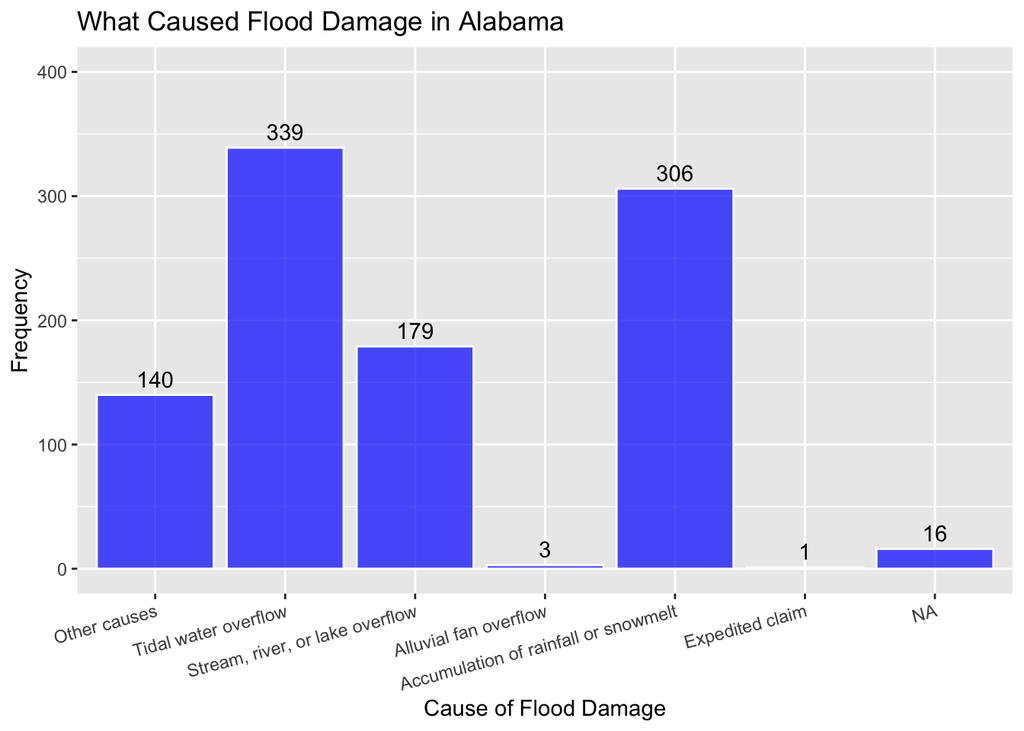

```r
# Plot bar chart for Alabama with labels
AL_damage = subset(claims, state == 'AL')
ggplot(AL_damage, aes(x = factor(causeOfDamage, labels = cause_labels))) +
  geom_bar(fill = "blue", color = "white", alpha = 0.7) +
  labs(title = "What Caused Flood Damage in Alabama",
       x = "Cause of Flood Damage",
       y = "Frequency") +
  scale_y_continuous(limits = c(0, 400)) +
  geom_text(aes(label = ..count..), stat = "count", vjust = -0.5, color = "black") +
  theme(axis.text.x = element_text(angle = 15, hjust = 1))
```

## Is flooding in Alabama So Bad Because of no Floodproof Strucutres?

[figure not shown]

```r
#are structures in Alabama flood proofed?
ggplot(claims, aes(x = state, fill = floodproofedIndicator)) +
  geom_bar(fill = "blue", color = "white", alpha = 0.7) +
  labs(title = "Floodproofing Status of Building by State",
       x = "Floodproof Indicator",
       y = "Frequency") + scale_y_continuous(limits = c(0,1100)) + geom_text(aes(label = ..count..), stat = "count", vjust = -0.5, color = "black")
```

Unfortunately, there aren’t many datasets available online on how many buildings in the U.S. are waterproof, so we can only speculate based on the available information that the substantial number of claims in Alabama may be attributed to insufficient floodproofing measures in the affected structures.